# Percentage of colocalizing mCherry-tagged proteins with Ede1-EGFP nuages in 3∆ background

Last compiled on February 02, 2022

## Experiment

### Rationale

The aim of the experiment was to determine whether mCherry-tagged endocytic proteins co-localize with Ede1-EGFP marked droplets in *apl3∆ yap1801∆ yap1802∆* yeast cells.

### Imaging and analysis

Two-color single planes were acquired on the Olympus IX81 equipped with a 100x/1.49 objective.

Measuring colocalization by correlation did not prove not very useful when applied to entire cells, since all endocytic proteins are correlated in intensity in major regions (background, cytoplasm and genuine endocytic patches).

I decided that a manual assessment would be more trustworthy. Regions of interest containing Ede1-EGFP droplets were cropped out of both channel images based *only* on the examination of the GFP channel. I used the ImageJ macro `blindAnalysis` to sequentially display all images at random, blinding me to the strain of origin, and recording a binary decision about colocalization for each image.

### Strain list

| strain | target |
| --- | --- |
| MKY3471 | Syp1 |
| MKY3454 | Ent1 |
| MKY3472 | Sla2 |
| MKY3483 | End3 |
| MKY3496 | Pan1 |
| MKY0578 | Sla1 |
| MKY3485 | Las17 |
| MKY3497 | Myo5 |
| MKY0583 | Abp1 |
| MKY3487 | Rvs167 |

## Results

### Individual datasets

Percentage of colocalizing condensate for each target protein in each dataset.

x: number of colocalisations, n: total number of analyzed condensates, p: x / n, p_min and p_max: estimates of binomial confidence interval based on sample size, by Wilson’s method.

| target | dataset | x | n | p | p_min | p_max |
| --- | --- | --- | --- | --- | --- | --- |
| Syp1 | 1 | 54 | 56 | 0.9642857 | 0.8788122 | 0.9901506 |
| Syp1 | 2 | 73 | 73 | 1.0000000 | 0.9500080 | 1.0000000 |
| Syp1 | 3 | 79 | 79 | 1.0000000 | 0.9536288 | 1.0000000 |
| Ent1 | 1 | 53 | 56 | 0.9464286 | 0.8539269 | 0.9816142 |
| Ent1 | 2 | 49 | 49 | 1.0000000 | 0.9273022 | 1.0000000 |
| Ent1 | 3 | 53 | 57 | 0.9298246 | 0.8329983 | 0.9723736 |
| Sla2 | 1 | 62 | 62 | 1.0000000 | 0.9416559 | 1.0000000 |
| Sla2 | 2 | 39 | 39 | 1.0000000 | 0.9103331 | 1.0000000 |
| Sla2 | 3 | 69 | 70 | 0.9857143 | 0.9234181 | 0.9992672 |
| End3 | 1 | 63 | 63 | 1.0000000 | 0.9425288 | 1.0000000 |
| End3 | 2 | 51 | 51 | 1.0000000 | 0.9299534 | 1.0000000 |
| End3 | 3 | 55 | 56 | 0.9821429 | 0.9055436 | 0.9990840 |
| Pan1 | 1 | 66 | 68 | 0.9705882 | 0.8989537 | 0.9918968 |
| Pan1 | 2 | 38 | 40 | 0.9500000 | 0.8349612 | 0.9861793 |
| Pan1 | 3 | 37 | 37 | 1.0000000 | 0.9059422 | 1.0000000 |
| Sla1 | 1 | 62 | 66 | 0.9393939 | 0.8542709 | 0.9761814 |
| Sla1 | 2 | 43 | 46 | 0.9347826 | 0.8249726 | 0.9775721 |
| Sla1 | 3 | 47 | 50 | 0.9400000 | 0.8378291 | 0.9793850 |
| Las17 | 1 | 53 | 54 | 0.9814815 | 0.9022856 | 0.9990501 |
| Las17 | 2 | 49 | 55 | 0.8909091 | 0.7817445 | 0.9490327 |
| Las17 | 3 | 57 | 61 | 0.9344262 | 0.8431720 | 0.9742063 |
| Myo5 | 1 | 20 | 52 | 0.3846154 | 0.2647046 | 0.5204013 |
| Myo5 | 2 | 23 | 48 | 0.4791667 | 0.3447132 | 0.6167077 |
| Myo5 | 3 | 14 | 36 | 0.3888889 | 0.2478487 | 0.5513554 |
| Abp1 | 1 | 26 | 98 | 0.2653061 | 0.1879572 | 0.3603603 |
| Abp1 | 2 | 8 | 71 | 0.1126761 | 0.0582127 | 0.2069005 |
| Abp1 | 3 | 9 | 40 | 0.2250000 | 0.1231609 | 0.3750310 |
| Rvs167 | 1 | 4 | 57 | 0.0701754 | 0.0276264 | 0.1670017 |
| Rvs167 | 2 | 11 | 70 | 0.1571429 | 0.0900762 | 0.2598825 |
| Rvs167 | 3 | 3 | 51 | 0.0588235 | 0.0202066 | 0.1592463 |

### Averaged datasets

Percentage of colocalizing condensates for each target protein, arithmetic mean ± SD from 3 datasets.

| target | mean | sd | n |
| --- | --- | --- | --- |
| Syp1 | 0.9880952 | 0.0206197 | 3 |
| Ent1 | 0.9587510 | 0.0366747 | 3 |
| Sla2 | 0.9952381 | 0.0082479 | 3 |
| End3 | 0.9940476 | 0.0103098 | 3 |
| Pan1 | 0.9735294 | 0.0251294 | 3 |
| Sla1 | 0.9380588 | 0.0028534 | 3 |
| Las17 | 0.9356056 | 0.0452977 | 3 |
| Myo5 | 0.4175570 | 0.0533983 | 3 |
| Abp1 | 0.2009941 | 0.0790961 | 3 |
| Rvs167 | 0.0953806 | 0.0537880 | 3 |

## Plot

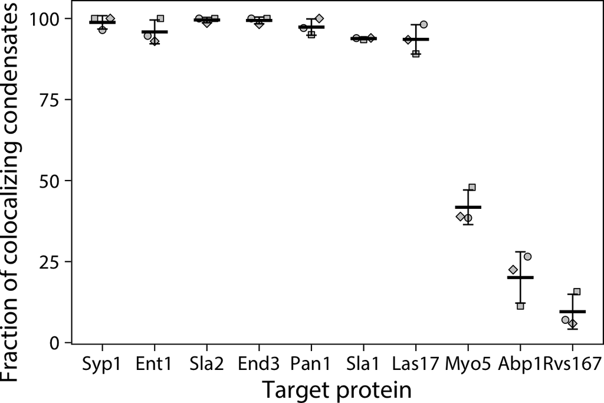

## Source data

### .csv

Download colocalisation_data.csv

### .RData

Download colocalisation_data.RData